# Reproducible Research Assignment 1

PA Defossez

26 mars 2017

## Download data

Show any code that is needed to Load the data (i.e. read.csv()) Process/transform the data (if necessary) into a format suitable for your analysis

```r
library(dplyr)
activity <- read.csv("activity.csv", header=TRUE)
```

## Change format date

```r
activity$date <- as.Date(as.character(activity$date), "%Y-%m-%d")
```

## What is mean total number of steps taken per day?

For this part of the assignment, you can ignore the missing values in the dataset.

```
Make a histogram of the total number of steps taken each day
```

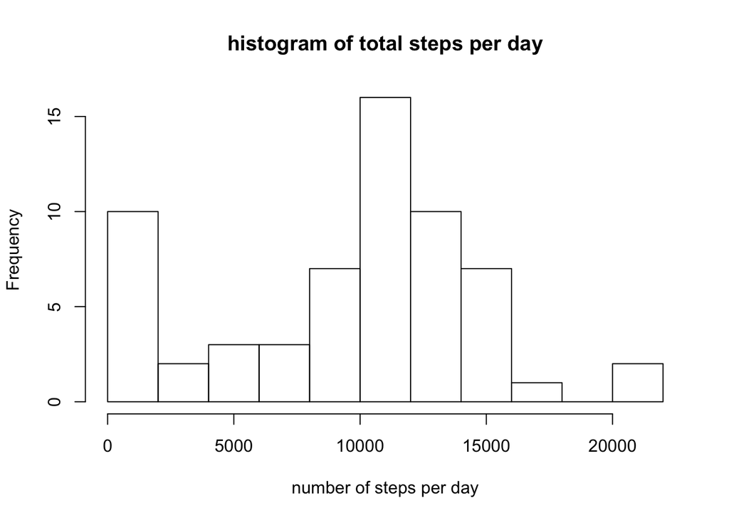

```r
histvalues <- activity %>% group_by(date) %>% summarize(total=sum(steps, na.rm=TRUE))

hist(histvalues$total, xlab="number of steps per day", main="histogram of total steps per day", breaks=10)
```

Calculate and report the mean and median total number of steps taken per day

```r
mean(histvalues$total)
```

```
## [1] 9354.23
```

```r
median(histvalues$total)
```

```
## [1] 10395
```

## What is the average daily activity pattern?

Make a time series plot (i.e. type = “l”) of the 5-minute interval (x-axis) and the average number of steps taken, averaged across all days (y-axis)

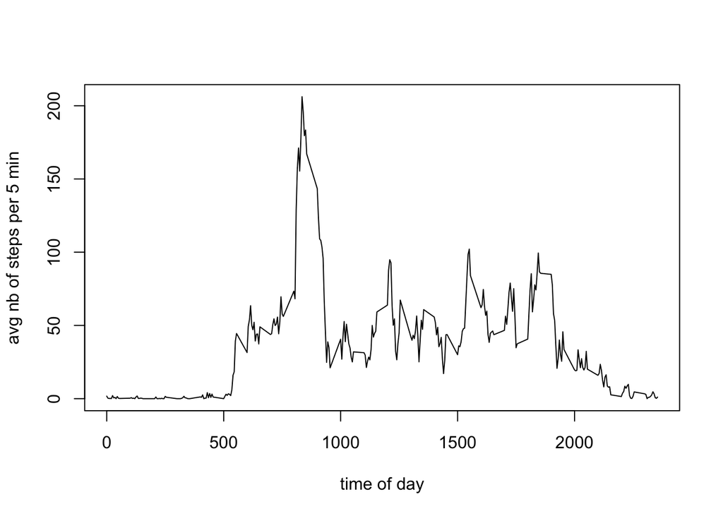

```r
timeseries <- activity %>% group_by(interval) %>% summarise (mean=mean(steps, na.rm=TRUE))

plot(timeseries$interval, timeseries$mean, type="l", xlab="time of day", ylab="avg nb of steps per 5 min")
```

Which 5-minute interval, on average across all the days in the dataset, contains the maximum number of steps?

```r
timeseries[which.max(timeseries$mean),1]
```

```
## # A tibble: 1 x 1
##   interval
##      <int>
## 1      835
```

## Imputing missing values

Note that there are a number of days/intervals where there are missing values (coded as NA). The presence of missing days may introduce bias into some calculations or summaries of the data.

```
Calculate and report the total number of missing values in the dataset (i.e. the total number of rows with NAs)
```

```r
sum(is.na(activity$steps))
```

```
## [1] 2304
```

Devise a strategy for filling in all of the missing values in the dataset. The strategy does not need to be sophisticated. I used the mean for that 5-minute interval. Create a new dataset that is equal to the original dataset but with the missing data filled in.

```r
activity2 <- cbind(activity, timeseries$mean)

names(activity2) <- c("steps","date","interval","default")

for (i in 1:length(activity2$interval)) {
        if (is.na(activity2[i,1])) {activity2[i,1] <- activity2[i,4]}
}
```

Re-draw histogram with the completed series

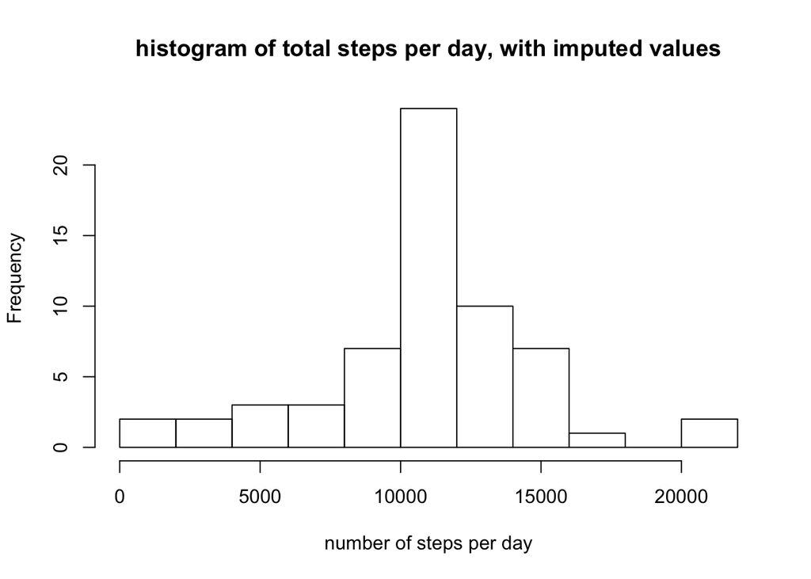

```r
histvalues2 <- activity2 %>% group_by(date) %>% summarize(total=sum(steps))

hist(histvalues2$total, xlab="number of steps per day", main="histogram of total steps per day, with imputed values", breaks=10)
```

Re-calculate mean and median

```r
mean(histvalues2$total)
```

```
## [1] 10766.19
```

```r
median(histvalues2$total)
```

```
## [1] 10766.19
```

## Are there differences in activity patterns between weekdays and weekends?

Create a new factor variable in the dataset with two levels – “weekday” and “weekend” indicating whether a given date is a weekday or weekend day.

```r
activity2$day <- weekdays(activity2$date)

daytype <- function(day) {
        if (day %in% c("Samedi", "Dimanche")) {
                "weekend"
        } else {
                "weekday"
        }
}
activity2$daytype <- as.factor(sapply(activity2$day, daytype))
```

Make a panel plot containing a time series plot (i.e. type = “l”) of the 5-minute interval (x-axis) and the average number of steps taken, averaged across all weekday days or weekend days (y-axis).

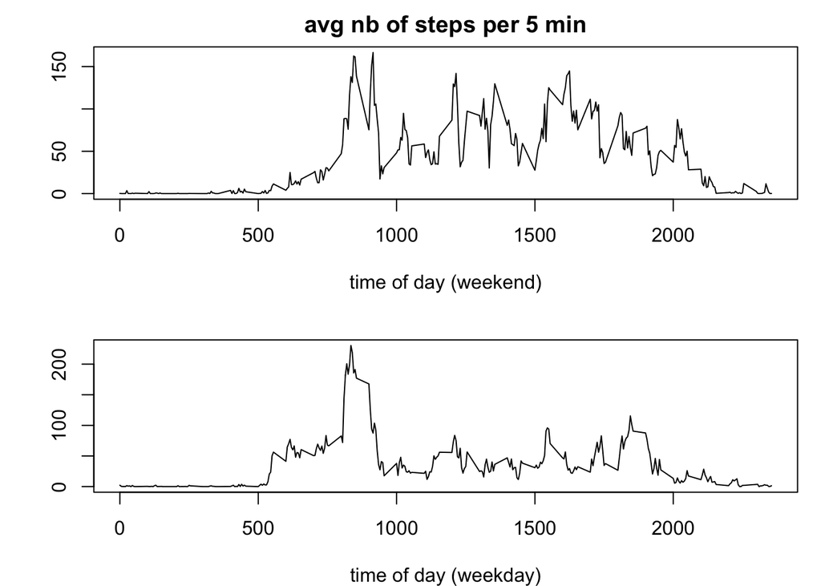

```r
par(mfrow=c(2,1), mar=c(4,4,2,1))
activity2WE <- filter(activity2, daytype=="weekend")
timeseriesWE <- activity2WE %>% group_by(interval) %>% summarise (mean=mean(steps))
plot(timeseriesWE$interval, timeseriesWE$mean, type="l", xlab="time of day (weekend)", ylab="", main="avg nb of steps per 5 min")


activity2WD <- filter(activity2, daytype=="weekday")
timeseriesWD <- activity2WD %>% group_by(interval) %>% summarise (mean=mean(steps))
plot(timeseriesWD$interval, timeseriesWD$mean, type="l", xlab="time of day (weekday)", ylab="")
```